# Assignment 4 - k-Means for Clustering

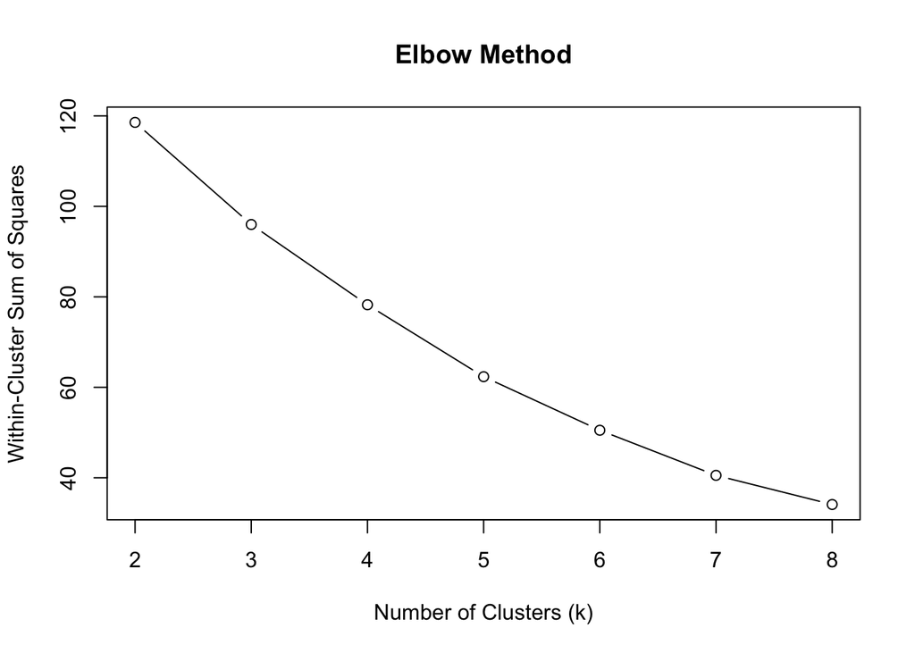

```r
# Elobow Method
set.seed(123)

k_values <- 2:8

wss <- sapply(k_values, function(k) {
  kmeans(
    data_scaled,
    centers = k,
    nstart = 50
  )$tot.withinss
})

plot(
  k_values, wss,
  type = "b",
  xlab = "Number of Clusters (k)",
  ylab = "Within-Cluster Sum of Squares",
  main = "Elbow Method"
)
```

```r
# Silhouette comparison
sil_scores <- sapply(k_values, function(k) {
  set.seed(123)

  model <- kmeans(
    data_scaled,
    centers = k,
    nstart = 50
  )

  mean(
    silhouette(
      model$cluster,
      dist(data_scaled)
    )[, 3]
  )
})

data.frame(
  k = k_values,
  WSS = round(wss, 2),
  Silhouette = round(sil_scores, 3)
)
```

```
##   k    WSS Silhouette
## 1 2 118.57      0.273
## 2 3  95.99      0.280
## 3 4  78.25      0.225
## 4 5  62.35      0.249
## 5 6  50.51      0.250
## 6 7  40.54      0.228
## 7 8  34.10      0.210
```

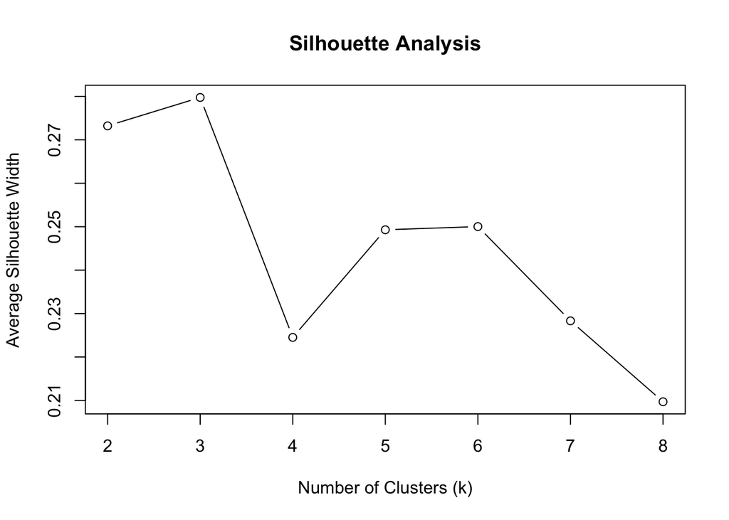

```r
plot(
  k_values, sil_scores,
  type = "b",
  xlab = "Number of Clusters (k)",
  ylab = "Average Silhouette Width",
  main = "Silhouette Analysis"
)
```

```r
# I compared different numbers of clusters using the elbow method and average silhouette width. The elbow method measures how much within-cluster variation decreases as more clusters are added. The silhouette score measures how well each firm fits its assigned cluster compared with other clusters. Based on the preliminary analysis, a three-cluster solution is a reasonable choice because it provides a balance between cluster separation and interpretability. The final choice should also be checked against the plots and silhouette results produced in R. I used nstart = 50 to try multiple initial cluster assignments and reduce the risk of obtaining a poor solution.
```

```r
# Running final k-Means Model
set.seed(123)

km3 <- kmeans(
  data_scaled,
  centers = 3,
  nstart = 50
)

# Cluster sizes
km3$size
```

```
## [1]  4 11  6
```

```r
# Cluster centers
round(km3$centers, 2)
```

```
##   Market_Cap  Beta PE_Ratio   ROE   ROA Asset_Turnover Leverage Rev_Growth
## 1      -0.61  0.27     1.31 -0.96 -1.02           0.23    -0.36      -0.58
## 2       0.67 -0.36    -0.28  0.66  0.83           0.46    -0.33      -0.29
## 3      -0.83  0.48    -0.37 -0.56 -0.85          -1.00     0.85       0.92
##   Net_Profit_Margin
## 1             -1.38
## 2              0.68
## 3             -0.33
```

```r
# Add cluster assignments to the original data
data$Cluster <- factor(km3$cluster)

# View each firm's cluster
data[, c("Symbol", "Name", "Cluster")]
```

```
##    Symbol                               Name Cluster
## 1     ABT                Abbott Laboratories       2
## 2     AGN                     Allergan, Inc.       1
## 3     AHM                       Amersham plc       1
## 4     AZN                    AstraZeneca PLC       2
## 5     AVE                            Aventis       3
## 6     BAY                           Bayer AG       1
## 7     BMY       Bristol-Myers Squibb Company       2
## 8    CHTT                       Chattem, Inc       3
## 9     ELN              Elan Corporation, plc       3
## 10    LLY              Eli Lilly and Company       2
## 11    GSK                GlaxoSmithKline plc       2
## 12    IVX                   IVAX Corporation       3
## 13    JNJ                  Johnson & Johnson       2
## 14    MRX Medicis Pharmaceutical Corporation       3
## 15    MRK                  Merck & Co., Inc.       2
## 16    NVS                        Novartis AG       2
## 17    PFE                         Pfizer Inc       2
## 18    PHA              Pharmacia Corporation       1
## 19    SGP        Schering-Plough Corporation       2
## 20    WPI       Watson Pharmaceuticals, Inc.       3
## 21    WYE                              Wyeth       2
```

```r
# Question b: Interpret the clusters
# Calculate cluster Averages
cluster_means <- data %>%
  group_by(Cluster) %>%
  summarise(
    n = n(),
    across(
      all_of(num_cols),
      ~ mean(.x, na.rm = TRUE)
    ),
    .groups = "drop"
  )

kable(
  cluster_means,
  digits = 2,
  caption = "Average Financial Characteristics by Cluster"
)
```

Average Financial Characteristics by Cluster

| Cluster | n | Market_Cap | Beta | PE_Ratio | ROE | ROA | Asset_Turnover | Leverage | Rev_Growth | Net_Profit_Margin |
| --- | --- | --- | --- | --- | --- | --- | --- | --- | --- | --- |
| 1 | 4 | 21.75 | 0.60 | 46.90 | 11.3 | 5.10 | 0.75 | 0.30 | 7.01 | 6.65 |
| 2 | 11 | 97.11 | 0.43 | 20.95 | 35.7 | 14.95 | 0.80 | 0.33 | 10.16 | 20.17 |
| 3 | 6 | 9.23 | 0.65 | 19.43 | 17.3 | 5.98 | 0.48 | 1.25 | 23.49 | 13.52 |

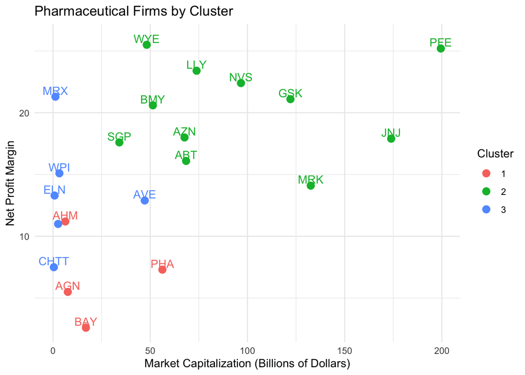

```r
# Visualize the Clusters
ggplot(
  data,
  aes(
    x = Market_Cap,
    y = Net_Profit_Margin,
    color = Cluster,
    label = Symbol
  )
) +
  geom_point(size = 3) +
  geom_text(
    nudge_y = 0.5,
    check_overlap = TRUE,
    show.legend = FALSE
  ) +
  labs(
    title = "Pharmaceutical Firms by Cluster",
    x = "Market Capitalization (Billions of Dollars)",
    y = "Net Profit Margin"
  ) +
  theme_minimal()
```

```r
# The three clusters represent firms with different combinations of financial characteristics. The cluster averages help identify these differences. One group consists of smaller firms with relatively high estimated revenue growth and higher leverage. Another group consists of large firms with stronger average returns on equity and assets, higher net profit margins, and lower beta. The remaining group has higher average price/earnings ratios but lower average profitability and revenue growth. These differences suggest that the pharmaceutical firms can be separated into groups based on their size, growth potential, profitability, valuation, and financial risk.
```

```r
# Question c: Examine the other three variables
# Compare brocker recommendation
recommendation_table <- table(
  data$Cluster,
  data$Median_Recommendation
)

recommendation_table
```

```
##
##     Hold Moderate Buy Moderate Sell Strong Buy
##   1    2            1             0          1
##   2    6            3             2          0
##   3    1            3             2          0
```

```r
# Proportions within each cluster
round(
  prop.table(recommendation_table, margin = 1),
  2
)
```

```
##
##     Hold Moderate Buy Moderate Sell Strong Buy
##   1 0.50         0.25          0.00       0.25
##   2 0.55         0.27          0.18       0.00
##   3 0.17         0.50          0.33       0.00
```

```r
# Compare headquarters locations
location_table <- table(
  data$Cluster,
  data$Location
)

location_table
```

```
##
##     CANADA FRANCE GERMANY IRELAND SWITZERLAND UK US
##   1      1      0       1       0           0  1  1
##   2      0      0       0       0           1  2  8
##   3      0      1       0       1           0  0  4
```

```r
round(
  prop.table(location_table, margin = 1),
  2
)
```

```
##
##     CANADA FRANCE GERMANY IRELAND SWITZERLAND   UK   US
##   1   0.25   0.00    0.25    0.00        0.00 0.25 0.25
##   2   0.00   0.00    0.00    0.00        0.09 0.18 0.73
##   3   0.00   0.17    0.00    0.17        0.00 0.00 0.67
```

```r
# Compare stock exchanges
exchange_table <- table(
  data$Cluster,
  data$Exchange
)

exchange_table
```

```
##
##     AMEX NASDAQ NYSE
##   1    0      0    4
##   2    0      0   11
##   3    1      1    4
```

```r
round(
  prop.table(exchange_table, margin = 1),
  2
)
```

```
##
##     AMEX NASDAQ NYSE
##   1 0.00   0.00 1.00
##   2 0.00   0.00 1.00
##   3 0.17   0.17 0.67
```

```r
# The additional variables show some patterns across the clusters, but they do not completely distinguish the groups. In the preliminary three-cluster solution, one cluster contains only firms listed on the NYSE and is dominated by US-headquartered firms. Another cluster is also mostly US-headquartered but includes firms listed on different exchanges. The third cluster contains only NYSE-listed firms, but its companies have headquarters in several countries. Broker recommendations also vary across the clusters. One group has more Moderate Buy recommendations, another has more Hold recommendations, and the remaining group includes Hold, Moderate Buy, and Strong Buy recommendations. Overall, the results suggest some association between financial clusters and the additional variables. However, the patterns overlap, and the small sample of 21 firms limits the conclusions that can be drawn.
```

```r
# Question d: Give each cluster an appropriate name
data %>%
  select(
    Symbol,
    Name,
    Cluster,
    all_of(num_cols),
    Median_Recommendation,
    Location,
    Exchange
  ) %>%
  arrange(Cluster) %>%
  kable(
    digits = 2,
    caption = "Company Assignments and Financial Characteristics"
  )
```

Company Assignments and Financial Characteristics

| Symbol | Name | Cluster | Market_Cap | Beta | PE_Ratio | ROE | ROA | Asset_Turnover | Leverage | Rev_Growth | Net_Profit_Margin | Median_Recommendation | Location | Exchange |
| --- | --- | --- | --- | --- | --- | --- | --- | --- | --- | --- | --- | --- | --- | --- |
| AGN | Allergan, Inc. | 1 | 7.58 | 0.41 | 82.5 | 12.9 | 5.5 | 0.9 | 0.60 | 9.16 | 5.5 | Moderate Buy | CANADA | NYSE |
| AHM | Amersham plc | 1 | 6.30 | 0.46 | 20.7 | 14.9 | 7.8 | 0.9 | 0.27 | 7.05 | 11.2 | Strong Buy | UK | NYSE |
| BAY | Bayer AG | 1 | 16.90 | 1.11 | 27.9 | 3.9 | 1.4 | 0.6 | 0.00 | -3.17 | 2.6 | Hold | GERMANY | NYSE |
| PHA | Pharmacia Corporation | 1 | 56.24 | 0.40 | 56.5 | 13.5 | 5.7 | 0.6 | 0.35 | 15.00 | 7.3 | Hold | US | NYSE |
| ABT | Abbott Laboratories | 2 | 68.44 | 0.32 | 24.7 | 26.4 | 11.8 | 0.7 | 0.42 | 7.54 | 16.1 | Moderate Buy | US | NYSE |
| AZN | AstraZeneca PLC | 2 | 67.63 | 0.52 | 21.5 | 27.4 | 15.4 | 0.9 | 0.00 | 15.00 | 18.0 | Moderate Sell | UK | NYSE |
| BMY | Bristol-Myers Squibb Company | 2 | 51.33 | 0.50 | 13.9 | 34.8 | 15.1 | 0.9 | 0.57 | 2.70 | 20.6 | Moderate Sell | US | NYSE |
| LLY | Eli Lilly and Company | 2 | 73.84 | 0.18 | 27.9 | 31.0 | 13.5 | 0.6 | 0.53 | 6.21 | 23.4 | Hold | US | NYSE |
| GSK | GlaxoSmithKline plc | 2 | 122.11 | 0.35 | 18.0 | 62.9 | 20.3 | 1.0 | 0.34 | 21.87 | 21.1 | Hold | UK | NYSE |
| JNJ | Johnson & Johnson | 2 | 173.93 | 0.46 | 28.4 | 28.6 | 16.3 | 0.9 | 0.10 | 9.37 | 17.9 | Moderate Buy | US | NYSE |
| MRK | Merck & Co., Inc. | 2 | 132.56 | 0.46 | 18.9 | 40.6 | 15.0 | 1.1 | 0.28 | 17.35 | 14.1 | Hold | US | NYSE |
| NVS | Novartis AG | 2 | 96.65 | 0.19 | 21.6 | 17.9 | 11.2 | 0.5 | 0.06 | -2.69 | 22.4 | Hold | SWITZERLAND | NYSE |
| PFE | Pfizer Inc | 2 | 199.47 | 0.65 | 23.6 | 45.6 | 19.2 | 0.8 | 0.16 | 25.54 | 25.2 | Moderate Buy | US | NYSE |
| SGP | Schering-Plough Corporation | 2 | 34.10 | 0.51 | 18.9 | 22.6 | 13.3 | 0.8 | 0.00 | 8.56 | 17.6 | Hold | US | NYSE |
| WYE | Wyeth | 2 | 48.19 | 0.63 | 13.1 | 54.9 | 13.4 | 0.6 | 1.12 | 0.36 | 25.5 | Hold | US | NYSE |
| AVE | Aventis | 3 | 47.16 | 0.32 | 20.1 | 21.8 | 7.5 | 0.6 | 0.34 | 26.81 | 12.9 | Moderate Buy | FRANCE | NYSE |
| CHTT | Chattem, Inc | 3 | 0.41 | 0.85 | 26.0 | 24.1 | 4.3 | 0.6 | 3.51 | 6.38 | 7.5 | Moderate Buy | US | NASDAQ |
| ELN | Elan Corporation, plc | 3 | 0.78 | 1.08 | 3.6 | 15.1 | 5.1 | 0.3 | 1.07 | 34.21 | 13.3 | Moderate Sell | IRELAND | NYSE |
| IVX | IVAX Corporation | 3 | 2.60 | 0.65 | 19.9 | 21.4 | 6.8 | 0.6 | 1.45 | 13.99 | 11.0 | Hold | US | AMEX |
| MRX | Medicis Pharmaceutical Corporation | 3 | 1.20 | 0.75 | 28.6 | 11.2 | 5.4 | 0.3 | 0.93 | 30.37 | 21.3 | Moderate Buy | US | NYSE |
| WPI | Watson Pharmaceuticals, Inc. | 3 | 3.26 | 0.24 | 18.4 | 10.2 | 6.8 | 0.5 | 0.20 | 29.18 | 15.1 | Moderate Sell | US | NYSE |

## The k-Means clustering analysis helped identify three groups among the 21 pharmaceutical firms using nine numerical financial variables. Standardizing the variables ensured that differences in measurement scales did not unfairly influence the clustering process. The clusters showed differences in market capitalization, profitability, revenue growth, valuation, and leverage. The analysis also showed that broker recommendations, headquarters locations, and stock exchanges provide additional context for understanding the groups. However, these variables did not completely separate the clusters. Overall, k-Means was useful for exploring the financial structure of the pharmaceutical industry and identifying firms with similar financial characteristics.